# Investigating Differentially Expressed Genes in Latent HIV+ T Cells

Paul Gaudin

4/10/2019

## Introduction

Currently, HIV can be treated but not cured. As of 2017, there were an estimated 36.9 million people living with HIV globally, only 21.7 million of which were accessing antiretroviral therapy (ART).<sup>1</sup> Additionally, approximately 9.4 million people do not know they are living with HIV, and there were about 1.8 new infections, and an estimated 940,000 people died from AIDS-related illnesses in 2017.<sup>1</sup> While a vaccine is often discussed as the long-term solution for ending the AIDS epidemic, less talked about is finding a cure for the millions already infected with HIV. Additionally, while treatment of HIV is now highly effective, with the ability to lower viral loads to undetectable and untransmittable levels, it is still far from perfect. Not only do many people not have access to antiretroviral therapy, especially in developing countries, but in the US the average cost of HIV treatment and related health care is on average about $20,000 (as of 2006).<sup>2</sup> Furthermore, side effects are also common in ART, and can include appetite loss, lipodystrophy, diarrhea, fatigue, mood changes, depression, anxiety, nausea and vomiting, rashes, trouble sleeping, and more. These side effects, especially in developing countries such as Cameroon, are a strong predictor of non-adherence to treatment regimens, causing many patients to forgo ART.<sup>3</sup>

Latency is seen as the largest barrier to eliminating HIV in HIV positive patients, as a state of latent infection in individual T cells persists indefinitely in patients on ART.<sup>4</sup> The mechanisms that allow latency are complex, but are known to include the absence of key host transcription factors and Tat, the presence of epigenetic changes that inhibit HIV expression, and the presence of factors involved in transcriptional interference.<sup>4</sup>

As HIV released from latently infected T cells can be blocked from additional replication by ART, approaches for reactivating stable latent viruses within T cell reservoirs has been identified as a potential route for eliminating HIV reservoirs in HIV positive patients.<sup>4</sup> This approach for elimination has been termed as ‘shock and kill,’ however it so far has only seen limited success.<sup>5</sup> Approaches for shock and kill have utilized many molecular mechanisms involved in HIV-latency, which include Latency-reversing agents (LRAs) such as include protein kinase C (PKC) agonists, histone deacetylase inhibitors (HDACi), histone methylation inhibitors (HMTi), DNA methyltransferase inhibitors (DNMTi), inhibitors of bromodomain and extraterminal (BET) domain proteins (BETi), or unclassified agents such as disulfiram.<sup>4,6</sup> However, as with PKC agonists, a major drawback for these approaches includes their lack of specificity for latently infected cells.<sup>4</sup> Furthermore, the level of reactivation, the diversity of reactivation in differing cell types, optimal time schedules of LRA treatment, the stochastic nature of the induction of latent HIV, and HIV’s dynamic properties all pose challenges to shock and kill.<sup>6</sup>

An alternative approach to shock and kill is the more newly proposed, and less investigated, ‘lock’ route.<sup>6</sup> This route would utilize strategies that would lock the virus into deep latency, permanently preventing any downstream viral reactivation. Molecules of interest in this route namely include those that interact with the Tat protein, which plays a critical role in HIV transcription, as well as others such as heat shock protein 90, which plays a necessary role in viral transcription under hyperthermic conditions.<sup>6</sup>

Latently infected cells have been seen to maintain their latency via several mechanisms that act predominantly at the transcriptional level, as well as some at the post-transcriptional level.<sup>6</sup> Hence, one could predict that the proteins and underlying transcriptomes of a latent infected cell would differ from that of a non-infected cell. Assuming there are differences in the transcriptomes of the latently infected versus non-infected T-cells, illuminating these differences could be crucial in advancing either the shock and kill or lock techniques for eliminating or permanently preventing further replication of the HIV virus within an infected patient on ART. An example of this would be in identifying transmembrane proteins and surface receptors that may be unique to quiescent HIV-infected cells. If one were to identify a cell surface receptor unique to these cells, this receptor could be utilized in the development of a targeted therapy that directly targets cells containing an HIV reservoir. Another example would be in the identification of protein coding transcripts that code for intracellular proteins unique to latently infected cells, whereby these proteins may be necessary for the established dormancy of the virus, and if targeted, may allow for viral replication to be reestablished and downstream elimination by ART.

In my analyses, I am investigating the differential expression of RNA transcripts between quiescent HIV-infected CD4+ T cells and non-infected CD4+ T cells, under the hypothesis that there is differential expression in latently infected CD4+ T cells. The data and experimental design of my analyses is based of the data collected by the researchers Descours et al., presented in 2017 in a Nature article titled “CD32a is a marker of a CD4 T-cell HIV reservoir harboring replication-competent proviruses.”<sup>7</sup> In the first section of this article, the researchers describe the process by which they used an in vitro model of HIV-infected quiescent CD4 T-cells to screen for upregulated genes. To do this, the researchers used four HIV-negative controls that were then infected with HIV (with a green fluorescent reporter) after treatment with viral like particles containing the accessory VLP-vpx, which induces SAMHD1 degredation.<sup>7</sup> HIV latently infected and HIV-exposed cells were sorted via fluorescence-activated cell sorting (FACS) and total RNA was extracted and ultra-deep sequenced (see Figure 1).<sup>7</sup>

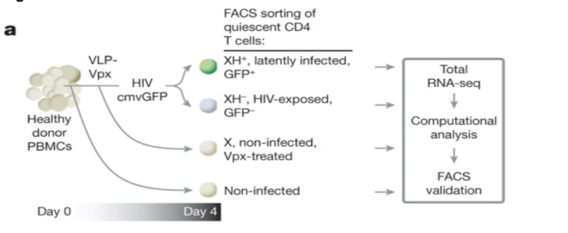

Figure 1. The general workflow by which latently HIV infected, HIV exposed, and non-infected but treated and non-infected or treated controls were obtained.<sup>7</sup>

Additionally, total RNA was extracted and ultra-deep sequenced from untreated and uninfected CD4 T cells as controls (Figure 1). What the researchers found were 103 exclusively differentially expressed genes in the HIV positive CD4 T-cells.<sup>7</sup> While the researchers carried out additional experimentation, mainly focused on the differentially expressed transmembrane CD32a protein marker in the HIV-infected T cells, the data I will be utilizing in my analyses is limited to this RNAseq NGS data generated, which can be found on the European Bioinformatics Institute website at: https://www.ebi.ac.uk/ena/data/view/PRJNA355967.

## Methods

To carry out this analysis on the NGS data I used FastQC/MultiQC to assess raw sequence NGS quality, the mapping tool STAR aligner to align reads to the Human Genome, Samtools to assess the alignment quality, the counting tool featureCounts to determine gene counts, and DESeq2 to normalize the data and do differential gene expression analysis.

#### Get Fastq Files

To get the Fastq files from https://www.ebi.ac.uk/ena/data/view/PRJNA355967 into my Raw_Project Reads directory I used the following SBATCH file:

```bash
#! /bin/bash -l

#SBATCH --partition=angsd_class
#SBATCH --nodes=1
#SBATCH --ntasks=1
#SBATCH --job-name=Project_Gets
#SBATCH --time=72:00:00   # HH/MM/SS
#SBATCH --mem=50G       # memory requested, units available: K,M,G,T

for sample in 007/SRR5071107/SRR5071107 008/SRR5071108/SRR5071108 009/SRR5071109/SRR5071109 000/SRR5071110/SRR5071110 001/SRR5071111/SRR5071111 002/SRR5071112/SRR5071112 003/SRR5071113/SRR5071113 004/SRR5071114/SRR5071114 005/SRR5071115/SRR5071115 006/SRR5071116/SRR5071116 007/SRR5071117/SRR5071117 008/SRR5071118/SRR5071118 009/SRR5071119/SRR5071119 000/SRR5071120/SRR5071120 001/SRR5071121/SRR5071121 002/SRR5071122/SRR5071122; do

    wget ftp://ftp.sra.ebi.ac.uk/vol1/fastq/SRR507/${sample}.fastq.gz /home/ptg4001/Raw_Project_Reads/

done
```

#### Run Fastqc and Multiqc on Fastq files

I used the following SBATCH File to analyze the Raw Reads:

```bash
#! /bin/bash -l

#SBATCH --partition=angsd_class
#SBATCH --nodes=1
#SBATCH --ntasks=1
#SBATCH --job-name=Project_Alignment
#SBATCH --time=72:00:00   # HH/MM/SS
#SBATCH --mem=100G       # memory requested, units available: K,M,G,T

spack load fastqc

fastqc /home/ptg4001/Raw_Project_Reads/*.gz --extract -o /home/ptg4001/Raw_Project_Reads_QC

spack load -r py-multiqc

multiqc -n project_raw.multiqc.html /home/ptg4001/Raw_Project_Reads_QC/.
```

Then to get the output html into my PC project directory (from within project directory on computer):

```bash
scp ptg4001@aristotle.med.cornell.edu:Project_Stats/project.multiqc.html .
```

Upon analyzing the output, I noticed that there would be no need to use trimgalore as my adapter content was low. Additionally, the sequences generally were of very high quality, however one point of concern is the high number of duplicate reads.

#### Run STAR Alignment

I used the STAR Aligner mainly for its compatibility with RNAseq data. As compared to BWA, STAR Aligner is splice aware - meaning that it can match transcripts to the genome that have their introns spliced out.

To do this, I first had to download the human reference genome, as well as the index file:

```bash
## on personal computer
wget http://hgdownload.cse.ucsc.edu/goldenPath/hg38/bigZips/hg38.2bit

wget http://hgdownload.cse.ucsc.edu/admin/exe/linux.x86_64/twoBitToFa

chmod +x twoBitToFa

./twoBitToFa hg38.2bit hg38.fa

##get to server
scp hg38.gtf ptg4001@aristotle.med.cornell.edu:


spack load star@2.6.1a

STAR --runMode genomeGenerate  --runThreadN 8 --genomeDir homo_sapien_STAR_index --genomeFastaFiles hg38.fa --sjdbGTFfile hg38.gtf --sjdbOverhang 100

##overhang 100 as avg read length was 101
```

Then used the following SBATCH File (after ref genome moved to athena using mv command)

```bash
#! /bin/bash -l

#SBATCH --partition=angsd_class
#SBATCH --nodes=1
#SBATCH --ntasks=1
#SBATCH --job-name=Project_Alignment
#SBATCH --time=72:00:00   # HH/MM/SS
#SBATCH --mem=100G       # memory requested, units available: K,M,G,T

spack load star@2.6.1a

for sample in 07 08 09 10 11 12 13 14 15 16 17 18 19 20 21 22; do

    STAR --runMode alignReads --runThreadN 8 --genomeDir /athena/angsd/scratch/Paul_HG_data  --readFilesIn /home/ptg4001/Raw_Project_Reads/SRR50711${sample}.fastq.gz --readFilesCommand zcat --outFileNamePrefix /home/ptg4001/Aligned_Project_Reads/SRR50711${sample}.  --outSAMtype BAM SortedByCoordinate

done
```

#### Run Stats, Flagstats, and Multiqc

Using the Samtools Stats and Flagstats will allow for preliminary quality analysis of the alignments, and Multiqc allows for easy visualization of Stat and Flagstat outputs in an HTML file.

Batch file:

```bash
#! /bin/bash -l

#SBATCH --partition=angsd_class
#SBATCH --nodes=1
#SBATCH --ntasks=1
#SBATCH --job-name=Project_Stats
#SBATCH --time=72:00:00   # HH/MM/SS
#SBATCH --mem=100G       # memory requested, units available: K,M,G,T

spack load samtools@1.9%gcc@6.3.0

for sample in 07 08 09 10 11 12 13 14 15 16 17 18 19 20 21 22; do

    samtools index /home/ptg4001/Aligned_Project_Reads/SRR50711${sample}.Aligned.sortedByCoord.out.bam

    samtools stats /home/ptg4001/Aligned_Project_Reads/SRR50711${sample}.Aligned.sortedByCoord.out.bam  > /home/ptg4001/Project_Stats/SRR50711${sample}_STAR.stats

    samtools flagstat /home/ptg4001/Aligned_Project_Reads/SRR50711${sample}.Aligned.sortedByCoord.out.bam > /home/ptg4001/Project_Stats/SRR50711${sample}_STAR.flagstats

done

spack load -r py-multiqc

multiqc -n project.multiqc.html /home/ptg4001/Project_Stats/.
```

Then to get the output html onto my PC:

```bash
scp ptg4001@aristotle.med.cornell.edu:project.multiqc.html .
```

In looking at these files, I noticed very high alignment scores to the reference genome, indicating that the STAR alignments went well.

#### Run featureCounts on Aligned Files

When using featureCounts, I used “-O” option, which allows for the reads to be counted according to meta-features, or rather the aggregation of a set of features (in this case genes), and -T 8 to utilize 8 threads.

Coded in an SBATCH File as follows:

```bash
#! /bin/bash -l

#SBATCH --partition=angsd_class
#SBATCH --nodes=1
#SBATCH --ntasks=1
#SBATCH --job-name=Project_Alignment
#SBATCH --time=72:00:00   # HH/MM/SS
#SBATCH --mem=100G       # memory requested, units available: K,M,G,T

spack load subread@1.6.2

featureCounts -a /home/ptg4001/hg38.gtf -O -o /home/ptg4001/Project_featurecounts.txt -T 8  /home/ptg4001/Aligned_Project_Reads/*.bam
```

#### Import featureCounts readcounts

```r
folder <- "./"
# reading in featureCounts output
readcounts <- read.table(paste0(folder, "Project_featurecounts.txt"),
header=TRUE)

head(readcounts)
```

[output not shown]

#### Get the gene transcript ids

Of note: the IDs for the transcripts are ensembl transcript id’s

```r
gene_trans_ids <- as.character(readcounts[,1])

gene_trans_ids <- gsub("\\..*","", gene_trans_ids)
```

#### Get the gene symbols from the ensembl, and save generated data frame reference as “ProjectGenesDataFrame.csv”

```r
library(biomaRt)

#Get symbols for Ensembl IDs
ensembl_ids = gene_trans_ids

mart = useMart(biomart = "ensembl", dataset = "hsapiens_gene_ensembl", host = "www.ensembl.org", ensemblRedirect = FALSE)

dat = getBM(
  values = ensembl_ids,
  filters = c("ensembl_transcript_id"),
  attributes = c("ensembl_transcript_id", "external_gene_name", "description"), # what to return
  mart = mart
)

write.table(
  dat,
  file = "biomart.tsv",
  quote = FALSE,
  sep = "\t",
  row.names = FALSE
)

gene.id.df <- data.frame(dat$external_gene_name, dat$description)

row.names(gene.id.df) <- dat$ensembl_transcript_id

write.csv(gene.id.df, file = "ProjectGenesDataFrame.csv")
```

#### Finish preparing count table for analysis in DESeq, which will be prepared and saved into counts_table_prepared.csv

```r
gene.id.df <- read.csv("ProjectGenesDataFrame.csv")

count_table_adjusted <- readcounts[,7:22]

row_names_as_symbols <- c();

for(i in 1:length(gene_trans_ids)){
  if(is.na(as.character(gene.id.df[gene_trans_ids[i],1]))){
    row_names_as_symbols <- c(row_names_as_symbols, gene_trans_ids[i]);
  }
  else{
    row_names_as_symbols <- c(row_names_as_symbols, (as.character(gene.id.df[gene_trans_ids[i],1])));
  }
}

row.names(count_table_adjusted) <- row_names_as_symbols

save(row_names_as_symbols, file="row_names_as_symbols.rds")

counts_table_prepared <- count_table_adjusted[1,]
row.names(counts_table_prepared) <- row_names_as_symbols[1]

for(i in 2:length(row_names_as_symbols)){
  if (!(row_names_as_symbols[i] %in% row.names(counts_table_prepared))) {
    newRow <- count_table_adjusted[i,];
    row.names(newRow) <- row_names_as_symbols[i]
    counts_table_prepared[nrow(counts_table_prepared) + 1,] <- newRow
  }
  else{
    counts_table_prepared[row_names_as_symbols[i],] <- counts_table_prepared[row_names_as_symbols[i],] + count_table_adjusted[i,]
  }
}

column_names <- c("", "SRR5071107", "SRR5071108", "SRR5071109", "SRR5071110", "SRR5071111", "SRR5071112", "SRR5071113", "SRR5071114", "SRR5071115", "SRR5071116", "SRR5071117", "SRR5071118", "SRR5071119", "SRR5071120", "SRR5071121", "SRR5071122")

colnames(counts_table_prepared) <- column_names

ctpp <- counts_table_prepared[,2:17]

row_names <- c()

for(i in 1:dim(counts_table_prepared)[1]){
  row_names <- c(row_names, as.character(counts_table_prepared[i,2]))
}

counts_table_prepared <- ctpp

#save(row_names, file="row_names.rds")
#row.names(ctpp) <- row_names

write.csv(counts_table_prepared, file = "counts_table_prepared.csv")
```

#### Load the prepared data frame (seen here as “ctpp”) and then create a DESeq object using it

```r
ctpp <- read.csv(file = "counts_table_prepared.csv", row.names = 1)

column_names <- c("SRR5071107", "SRR5071108", "SRR5071109", "SRR5071110", "SRR5071111", "SRR5071112", "SRR5071113", "SRR5071114", "SRR5071115", "SRR5071116", "SRR5071117", "SRR5071118", "SRR5071119", "SRR5071120", "SRR5071121", "SRR5071122")

sample_type = c("HIV_EXP_GFP_NEG", "HIV_EXP_GFP_NEG", "VLP_VPX_TREATED", "VLP_VPX_TREATED", "HIV_EXP_GFP_POS", "HIV_EXP_GFP_NEG", "VLP_VPX_TREATED", "NON_EXPOSED_OR_TREATED", "NON_EXPOSED_OR_TREATED", "HIV_EXP_GFP_POS", "HIV_EXP_GFP_NEG", "VLP_VPX_TREATED", "HIV_EXP_GFP_POS", "HIV_EXP_GFP_POS", "NON_EXPOSED_OR_TREATED", "NON_EXPOSED_OR_TREATED")

donor = c("Donor_4", "Donor_3", "Donor_4", "Donor_1", "Donor_1", "Donor_1", "Donor_3", "Donor_2", "Donor_1", "Donor_4", "Donor_2", "Donor_2", "Donor_3", "Donor_2", "Donor_3", "Donor_4")

column_data <- data.frame(sample_type, donor)

rownames(column_data) <- column_names[1:16]

library("DESeq2")

cts <- as.matrix(ctpp)

save(cts, file="cts.rds")

dds <- DESeqDataSetFromMatrix(countData = cts,
                              colData = column_data,
                              design= ~ donor + sample_type)

dds <- DESeq(dds)
```

#### Keep transripts which have a sum of 10 transcripts over all samples

```r
keep <- rowSums(counts(dds)) >= 10
dds <- dds[keep,]
```

```r
dds$sample_type <- relevel(dds$sample_type, ref = "HIV_EXP_GFP_NEG")
```

#### Set object “res” to contain the results of “HIV_EXP_GFP_POS” vs “HIV_EXP_GFP_NEG”

```r
res <- results(dds, contrast=c("sample_type","HIV_EXP_GFP_POS", "HIV_EXP_GFP_NEG"))

resultsNames(dds)
```

```
## [1] "Intercept"
## [2] "donor_Donor_2_vs_Donor_1"
## [3] "donor_Donor_3_vs_Donor_1"
## [4] "donor_Donor_4_vs_Donor_1"
## [5] "sample_type_HIV_EXP_GFP_POS_vs_HIV_EXP_GFP_NEG"
## [6] "sample_type_NON_EXPOSED_OR_TREATED_vs_HIV_EXP_GFP_NEG"
## [7] "sample_type_VLP_VPX_TREATED_vs_HIV_EXP_GFP_NEG"
```

#### Save another log-fold-counts object for later use that compares “HIV_EXP_GFP_POS” vs “HIV_EXP_GFP_NEG” as “resLFC”

```r
#resultsNames(dds)

resLFC <- lfcShrink(dds, coef="sample_type_HIV_EXP_GFP_POS_vs_HIV_EXP_GFP_NEG", type="apeglm")
```

```
## using 'apeglm' for LFC shrinkage. If used in published research, please cite:
##     Zhu, A., Ibrahim, J.G., Love, M.I. (2018) Heavy-tailed prior distributions for
##     sequence count data: removing the noise and preserving large differences.
##     Bioinformatics. https://doi.org/10.1093/bioinformatics/bty895
```

```r
summary(resLFC)
```

```
##
## out of 39470 with nonzero total read count
## adjusted p-value < 0.1
## LFC > 0 (up)       : 2996, 7.6%
## LFC < 0 (down)     : 2463, 6.2%
## outliers [1]       : 0, 0%
## low counts [2]     : 16070, 41%
## (mean count < 6)
## [1] see 'cooksCutoff' argument of ?results
## [2] see 'independentFiltering' argument of ?results
```

#### See how many genes are signifantly upregulated (cutoff < 1*(10^-8)) in “HIV_EXP_GFP_POS” vs “HIV_EXP_GFP_NEG”

```r
sum(res$padj < 1*(10^-8), na.rm=TRUE)
```

```
## [1] 585
```

```r
total_up_reg <- subset(res, res$padj < 1*(10^-8))

total_up_reg <- subset(total_up_reg, total_up_reg$log2FoldChange > 3)

nrow(total_up_reg)
```

```
## [1] 166
```

#### Create MA-plot log2 Fold Changes “HIV_EXP_GFP_POS” vs “HIV_EXP_GFP_NEG”

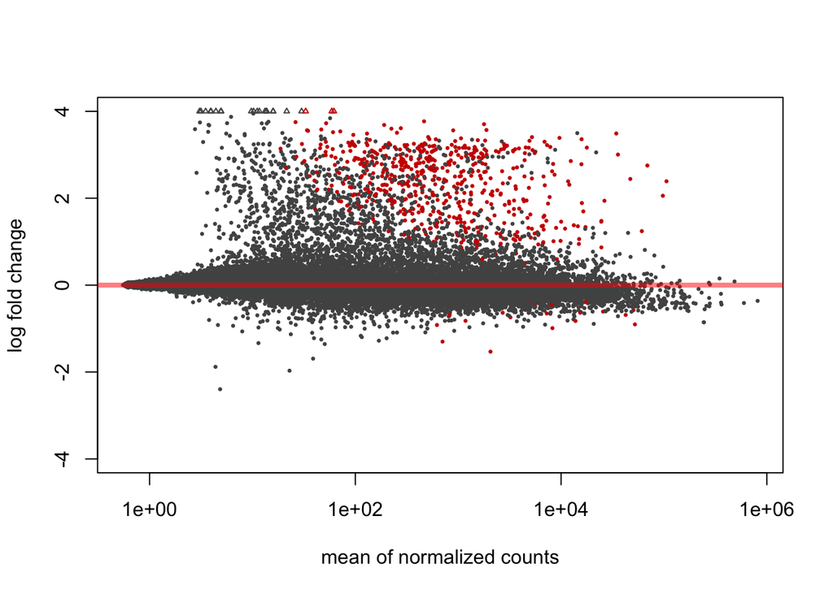

```r
plotMA(resLFC, alpha= 10^-8, ylim=c(-4,4))
```

#### Create Histogram of adjusted p-values of differentially expressed genes in “HIV_EXP_GFP_POS” vs “HIV_EXP_GFP_NEG”. Also remove values including NA adjusted pvalue

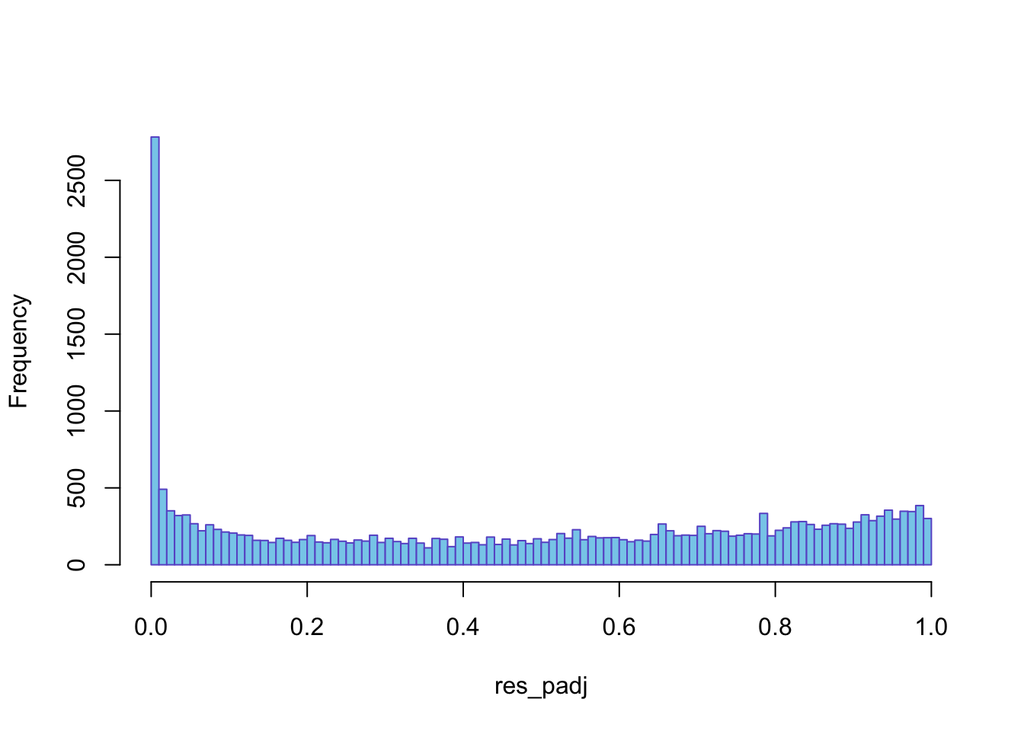

```r
res_padj <- res$padj[which(res$padj != "NA")]
hist(res_padj, breaks=100, col="skyblue", border="slateblue", main="")
```

#### Histogram of p-values under 10^-8

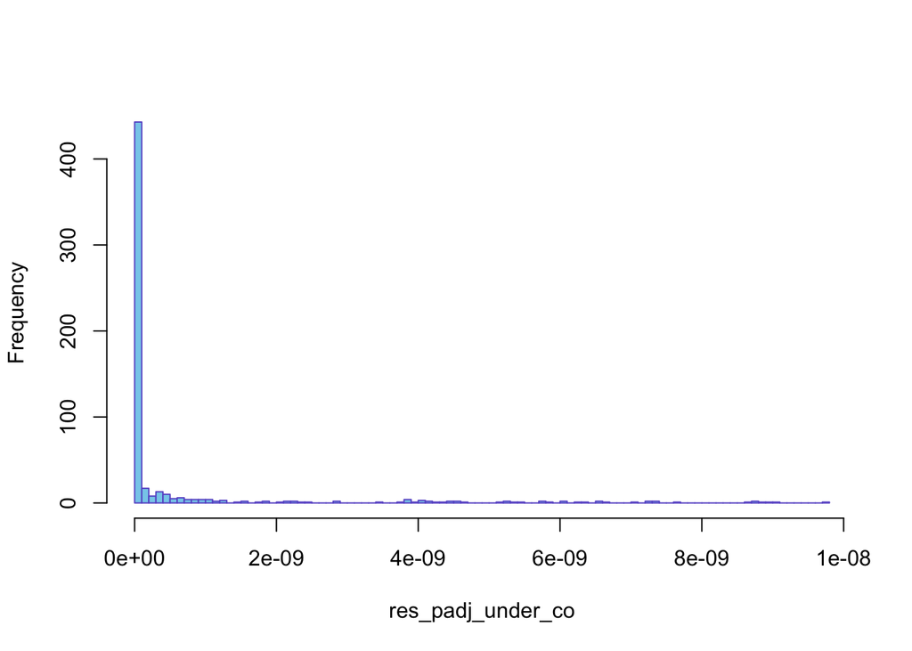

```r
res_padj_under_co <- res_padj[which(res_padj < 10^-8)]
hist(res_padj_under_co, breaks=100, col="skyblue", border="slateblue", main="")
```

#### Volcano plot of the log2FoldChange vs pvalues for expression in “HIV_EXP_GFP_POS” vs “HIV_EXP_GFP_NEG” samples

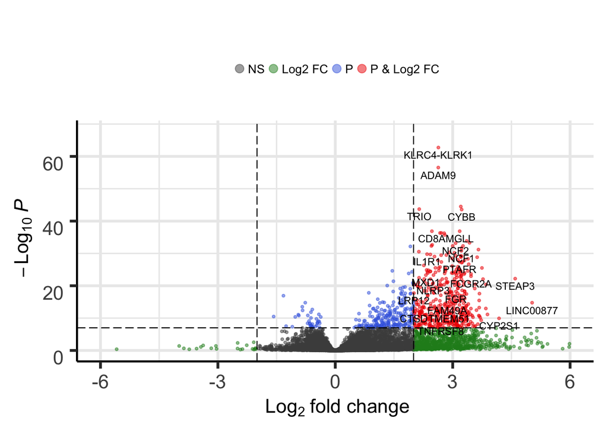

```r
library(EnhancedVolcano)

EnhancedVolcano(res, lab = rownames(res), x = "log2FoldChange",y = "padj", pCutoff = 10e-8,  xlim = c(-6, 6))
```